# 2024 Spatial Hackathon Vignette: Image Processing Tools

### Set-up

This vignette reflects some of our stretch goals for this Hackathon. Given neighbourhood identification in our previous vignettes, we wondered if it would be possible to integrate our neighbourhoods with H&E information (Aim 2 of this Hackathon). To that end, we developed some functions for image processing.

```r
## Dependencies for image processing
require(MASS)

## Load code from repository
package_dir = 'C:/Users/kwaje/Downloads/HACKATHON/CODE/TriangulaMarkovCoLocalizer/'
funcfs <- list.files(package_dir, pattern='.R', full.names = T)
sapply(funcfs[!grepl('neighbors_250_grids', funcfs)], function(x) source(x, local = F, chdir = T))
```

[output not shown]

Below are packages for plotting and quick data reading and manipulation. They are not compulsory for our code to run, but provide useful functionality.

```r
## Data loading
library(data.table)
library(readxl)

## Visualisation
library(ggplot2)
library(pheatmap)
library(viridis)

## Image processing functions
library(imager)
library(RBioFormats)

## Other functions
library(irlba)
```

### Preliminary image analysis

In the time given, we were able to achieve the following:

1. Stain deconvolution
2. Image gridding and unbiased clustering of Fourier transform spaces

We were unable, in the time allotted, figure out the translation of H&E image coordinates with that of the Xenium-derived cellular coordinates.

#### Stain deconvolution

We read images using the `RBioFormats` package, and quickly plot with the `imager` package. This allows us to load in a lower resolution without straining our resources.

```r
data_dir = 'C:/Users/kwaje/Downloads/HACKATHON/'
im_mod = 'he'
fs <- paste0(data_dir, 'Xenium_FFPE_Human_Breast_Cancer_Rep1_', im_mod, '_image.ome.tif')
meta <- RBioFormats::read.metadata(fs)
meta
```

```
ImageMetadata list of length 7

 series res sizeX sizeY sizeC sizeZ sizeT total
 1      1   30786 24241 3     1     1     3
 1      2   15393 12120 3     1     1     3
 1      3   7696  6060  3     1     1     3
 1      4   3848  3030  3     1     1     3
 1      5   1924  1515  3     1     1     3
 1      6   962   757   3     1     1     3
 1      7   481   378   3     1     1     3
```

```r
resolution <- RBioFormats::read.omexml(fs)
print(resolution)
```

[output not shown]

```r
resolution = 0.2125 #Microns per pixel
max_dim <- c(meta[[1]]$coreMetadata$sizeX, meta[[1]]$coreMetadata$sizeY)
im <- RBioFormats::read.image(fs, res = 4)
ima <-
  list('im' = im@.Data,
       'res' = resolution,
       'maxdim' = max_dim
       )
```

#### Stain deconvolution

Given a H&E image, one early pre-processing step is to separate the image into its H and E components. This is quickly achievable with matrix deconvolution. We use a pseudoinverse (via the `MASS` package) to ensure a least squares solution.

Entropy is calculated by comparing min-maxxed H and E matrices: i.e. H * log2(H) + E * log2(E).

```r
heList <- heDeconvolve(ima$im)
par(mfrow=c(2,2))
plot(as.cimg(ima$im))
for(i in 1:length(heList)){
  plot(as.cimg(heList[[i]]), main=names(heList)[i])
}
```

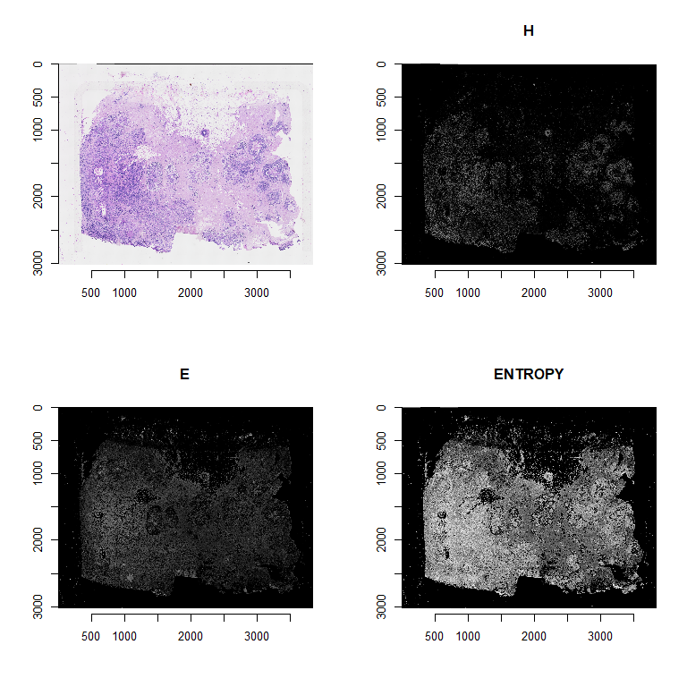

```r
par(mfrow=c(1,1))
```

The colours used in deconvolution are as below:

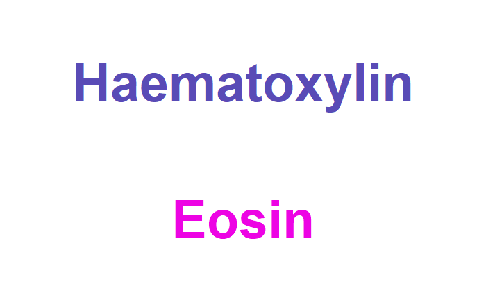

```r
ggplot(data.frame(
  'stain' = c('Haematoxylin', 'Eosin'),
  'colx' =  c('#594BB6', '#ED03E4')
  )) +
  geom_text( aes(x=stain, y=1, colour=colx, label=stain),
             fontface = 'bold', size = 20, hjust=0.5) +
  scale_colour_identity() +
  theme_void(base_size=10) +
  theme(legend.position = 'none') +
  coord_flip()
```

#### Image tiling and FFT scoring + NMF

The approach herein is based of this paper: PMID: 31855656. Briefly, we tile the images, apply a Hanning window to filter out high frequency noise, and perform a Fast Fourier Transform (FFT) to each tile. The frequency component can then be extracted and factorised with Non-Negative Matrix Factorisation (NMF) downstream, to get k anatomical regions.

This approach has the advantage of image analysis without the necessity of training a deep learning model (which requires a large well-annotated corpus to train on).

Tiling and gridding can be done separately for eosin and hematoxylin-deconvolved images (as below):

```r
tf <- tileFFTImage( list('H' = heList$H, 'E' = heList$E) )
```

[output not shown]

```r
tfList <- do.call(cbind, lapply(1:dim(tf)[3], function(x){
  return(as.vector(tf[,,x]))
}))
dim(tf)
```

```
[1]  128  100 7200
```

```r
dim(tfList)
```

```
[1] 12800  7200
```

We now perform NMF, with an arbitrary k.

```r
k = 6
set.seed(12345)
nmfd <- RcppML::nmf(tfList, k=k)
```

```
iter |      tol
---------------
   1 | 9.63e-01
   2 | 1.84e-01
   3 | 4.21e-02
   4 | 1.69e-02
   5 | 8.54e-03
   6 | 5.81e-03
   7 | 4.94e-03
   8 | 3.64e-03
   9 | 2.29e-03
  10 | 1.21e-03
  11 | 6.97e-04
  12 | 4.52e-04
  13 | 2.95e-04
```

[output cut: 26 more lines]

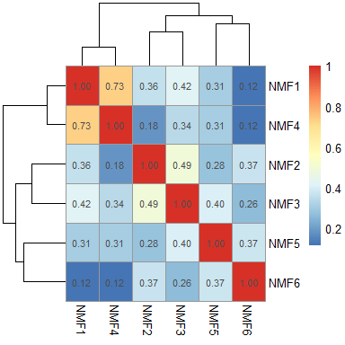

```r
h <- nmfd$h
w <- nmfd$w
colnames(w) <- paste0('NMF', sprintf(paste0('%0', nchar(k), 'd'), 1:k))
pheatmap(cor(w), display_numbers = T)
```

We can now plot factor loadings in space. So doing will allow us to identify regions of the H&E image with different H&E structures.

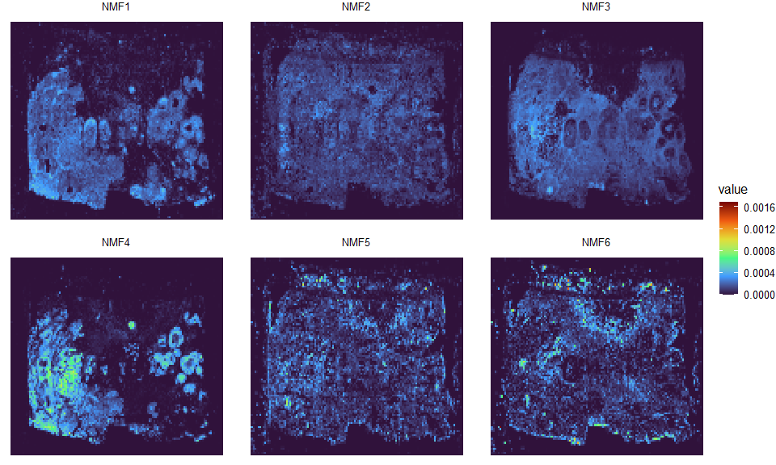

```r
tmp <- list()
for(i in 1:ncol(w)){
  df <- as.data.frame(as.cimg(matrix(w[,i], nrow=dim(tf)[1], ncol=dim(tf)[2])))
  df$NMF <- colnames(w)[i]
  tmp[[i]] <- df
}
tmp <- do.call(rbind, tmp)

ggplot(tmp) +
  geom_raster(aes(x=x, y=y, fill=value)) +
  theme_void(base_size=12) +
  scale_fill_viridis_c(option='turbo') +
  facet_wrap(~NMF) +
  scale_y_reverse()
```

It may eventually be possible to see how our cell abundance neighbourhoods (previous vignettes) match up with our tissue architecture neighbourhoods (above); but we did not have time to explore this further.